# When a picture isn’t worth 1000 words: making ggplot2 graphics accessible for blind users

Debra Warren

A thesis submitted in partial fulfillment of the requirements for the degree of Master of Professional Studies in Data Science, the University of Auckland, 2018

Abstract

Blind students and professionals in a variety of fields have a need to produce and interpret statistical graphics. The existing R package BrailleR provides support for blind users, including a function that describes R graphics in a textual format suitable for reading by screen readers, and another which allows interactive exploration of graphs by blind or low-vision users. Only simple graphs produced by a handful of base R graphics functions are supported. In this work the BrailleR functionality was extended to allow descriptions of graphs produced by the popular ggplot2 graphics package. The ggplot2 package provides a consistent and flexible framework for producing many different graph types, including complex graphs containing multiple panels or superimposed plot layers, so this work has significantly extended the variety of graphs to which blind users have access via BrailleR.

The design approach was to construct an object containing all relevant information about the graphic, which could then be reported on or explored in a variety of ways. A templating system was used to isolate the software from the exact grammar and language of the subsequent textual reporting. The developed system supports text-based reporting for a variety of ggplot2 graphics such as bar graphs, scatter plots, line graphs, and box plots, including faceted and layered graphics. Extensions to additional ggplot2 “geoms” should be relatively easy since the underlying structures are consistent. The developed system describes what might be called the *framework* of the graph (labels, axes, panels, legends, etc.) as well as listing the individual data item *contents*. The design approach supports the construction of filter functions to modify the information presented, and two simple examples were developed to demonstrate this flexibility. Use of the constructed object to drive interactive exploration was also piloted, leveraging the existing BrailleR functionality.

#### Acknowledgement

The author would like to thank the following people:

- her supervisor Paul Murrell for his always-insightful advice and direction and his cheerful encouragement,
- her co-supervisor Jonathan Godfrey for his enthusiasm, his insights into the needs of blind users of statistical software and his trust in incorporating the author’s work into his BrailleR package

# 1 Introduction

Students in many scientific and business disciplines are expected to take statistics courses, which include production and interpretation of statistical graphics. Professionals in many fields also need to produce statistical graphs for communication with co-workers or clients, or for academic publication. These tasks pose challenges for blind or vision-impaired students and professionals. Screen reader software enables blind users to consume text, but generally provides little information about the contents of graphics (though some will attempt to read text contained within the graphic).(Godfrey and Loots 2014)

R(R Core Team 2017) is a very popular statistical computing environment and language, which is used by many statistics students and professionals. It is also fairly accessible for blind users, as discussed below in section 2.4. R supports extension through user-created “packages”. One such existing package, BrailleR, provides a variety of functionality to assist blind users of R, including functionality to produce text descriptions of some existing base R graphics (for the blind user’s consumption via a screen reader).

This dissertation details an investigation that was undertaken into whether this existing functionality could be extended to graphics produced by the ggplot2 package, and describes the software that resulted from that investigation. Based on a “grammar of graphics” concept, ggplot2 supports production of a far wider variety of graphics than are currently supported by BrailleR, so the resulting software should significantly expand the variety of graphics that can be made accessible to blind users. It was found that the necessary descriptive information could be extracted from the ggplot2 graphics in a consistent and structured fashion and made available for text reporting or interactive exploration. Reporting could be provided for a wide range of different graphics, and the resulting extension has been deemed useful enough to be incorporated into the official BrailleR package.

As background, the existing BrailleR functionality will now be described in more detail, followed by a description of ggplot2 and the benefits of extending BrailleR functionality to support it.

## 1.1 BrailleR

The R package BrailleR(Godfrey, Sorge, and Bilton 2017) provides a collection of functionality aimed at assisting blind and vision-impaired people in their use of R software. Dr Godfrey, the primary author and maintainer of BrailleR, is a blind statistician and co-supervisor on this project.

The BrailleR package includes a function called VI for automatically producing text descriptions of the output of some R graphics functions (as well as descriptions of non-graphical items such as linear models). At the time of this work, VI could process histograms, box plots and stripcharts (a sort of one-dimensional scatter plot). These graphics are all produced by functions within the “base” R graphics system; the competing ggplot2 and underlying grid graphics system will be discussed in the next section.

The text descriptions produced by VI describe the layout of the graph including the axes and their labels, the title and other annotations, as well as the data values displayed by the graph. A sample histogram and its associated VI output are shown in Figure 1.

**Figure 1: Sample histogram with associated VI output**

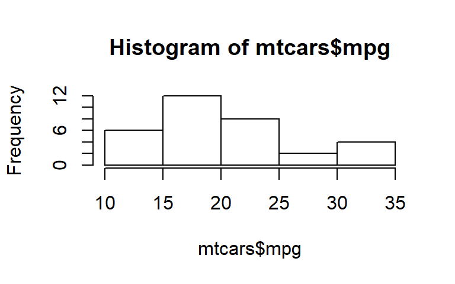

```r
h = hist(mtcars$mpg)
```

```r
VI(h)
```

```
This is a histogram, with the title: Histogram of mtcars$mpg
"mtcars$mpg" is marked on the x-axis.
Tick marks for the x-axis are at: 10, 15, 20, 25, 30, and 35
There are a total of 32 elements for this variable.
Tick marks for the y-axis are at: 0, 2, 4, 6, 8, 10, and 12
It has 5 bins with equal widths, starting at 10 and ending at 35 .
The mids and counts for the bins are:
mid = 12.5  count = 6
mid = 17.5  count = 12
mid = 22.5  count = 8
mid = 27.5  count = 2
mid = 32.5  count = 4
```

It should be noted that these previously-supported graphics are basically uni-variate (though box plots and stripcharts can be grouped by another variable) - as compared to bi-variate plot types such as scatter plots and line plots. Various aesthetics such as colour and shading lines can be specified, but are not reported by VI. One benefit of extension of the VI function to ggplot2 graphics is to enable handling of bi-variate graphs, including graphs with additional variables mapped using aesthetics such as colour or shape.

The second BrailleR function of interest for this project is MakeAccessibleSVG.(Fitzpatrick, Godfrey, and Sorge 2017; Godfrey, Murrell, and Sorge 2017) This function creates an interactive web page which allows blind or low-vision users to explore a graphic. MakeAccessibleSVG is an experimental function which currently has methods for graphics created with the histogram and box plot commands, and a partially implemented methods for scatter plots created by the “plot” function and for time series plots.

The web page created by MakeAccessibleSVG has the following components:

- an SVG representation of the graph
- A corresponding XML file which describes a hierarchical structure of the components of the SVG
- JavaScript which supports the interactivity, as described further below
- An html wrapper for the above components, including help text about the available navigation commands

The SVG object is created using the gridGraphics(Murrell 2017) and gridSVG(Murrell and Potter 2017) packages, which respectively convert base R graphics to grid graphics, and export those grid graphics as an SVG file. While grid graphics will be discussed later, for the purpose of understanding MakeAccessibleSVG this can simply be seen as a means to create an SVG representation.

The web page created by MakeAccessibleSVG displays the SVG version of the graphic at the top of the screen, in high contrast colours (with a few different options available). As the graphic is navigated hierarchically, this display zooms in to the sub-component currently being explored. Below this is a brief text description of the selected component (with two different levels of detail available), followed by the instructions for the supported commands. A partial screenshot is shown in Figure 2, with the x-axis as the selected component.

**Figure 2: Partial screenshot from MakeAccessibleSVG**

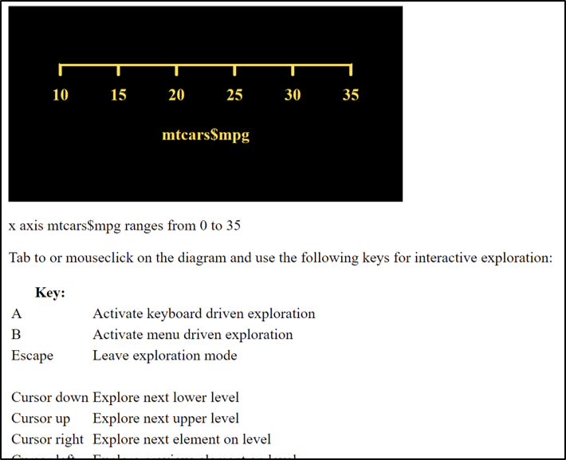

The user initiates the session by issuing the command MakeAccessibleSVG(x) where x is the graphical object. This opens the web page as shown above. Single-keystroke commands allow navigation around the diagram, as well as modifying various settings.

A fragment of a sample session might run as shown in Figure 3 (with navigation described and the resulting displayed text shown in quotes):

**Figure 3: Sample MakeAccessibleSVG output**

```
Web page opens
"Histogram of mtcars$mpg"
X - toggles to more detailed description mode
"Histogram showing 5 bars for mtcars$mpg over the range 10 to 35 and Frequency from 0 to 12"
down arrow - move to first child which is the title
"Title: Histogram of mtcars$mpg"
right arrow - move to next child
"x axis mtcars$mpg ranges from 0 to 35"
two more right arrows gets us to the body of the plot
"Histogram with 5 bars"
down arrow to first child which is bar 1
"Bar 1 between x values 10 and 15 with y value 6 and density 0.0375"
```

As part of this project the author implemented a simple proof of concept to demonstrate that the same functionality can be provided for similar histograms created by ggplot2 – and by extension, should be able to be provided for a much broader range of ggplot2 graphics.

Both VI and MakeAccessibleSVG are called as functions taking as their main parameter the object returned by the given base graphics function. Their functionality depends on the needed information about the graph structure and contents being captured in these returned objects, in a format suitable for extraction. The amount of information returned by base R graphics functions varies. In the case of histograms and stripcharts, a wrapper function is used within BrailleR to capture needed information from the function call that isn’t present in the returned object. Scatter plots and line charts are common and useful plot types that would also be desirable to process with VI. Unfortunately the base function “plot” that produces them returns no object at all, simply printing as a side effect, which makes it especially problematic for VI processing.

When drawing complex graphics with base R graphics, they are typically built up with multiple commands (e.g. “points”, “lines”) which add items to the plot. These additional functions simply draw directly onto the output canvas without returning objects, just as “plot” does, again making these graphics problematic for VI.

Furthermore, each base R graphics function returns an entirely different object, with information stored differently in each case. This means that developing each VI method for processing a new base R graphics type involves essentially starting from scratch – very little code if any can be reused from the prior functions. This was part of the motivation for looking to the ggplot2 package.

## 1.2 The ggplot2 package

The graphics previously processed by BrailleR are all “base R graphics”. The author aimed to extend the BrailleR VI functionality to objects produced using the popular ggplot2 graphics package by Hadley Wickham(Wickham 2016), which is built atop the “grid” graphics system developed by Paul Murrell(Murrell 2017). Based on the “grammar of graphics” concept, ggplot2 enables production of a wide variety of different chart types including multi-layered and faceted graphs, with an extremely flexible facility for modifying various aspects of the resulting graphic.

The ggplot2 package provides a command “qplot” (short for “quick plot”) which provides a simplified syntax, and is a wrapper to the more powerful “ggplot” syntax, which allows more complex plots to be constructed. As qplot is just a wrapper, the same “ggplot” object type results in either case. Many of the examples below use qplot syntax for simplicity, but the same object could be produced using ggplot and reported on in the same fashion.

Figure 4 shows some sample plots (from Wickham (2016)) and the commands used to produce them. It should be clear that fairly complex and varied plots can be produced quite simply.

**Figure 4: Examples of the plots that can be produced by ggplot2 (from Wickham (2016)): (a) a stacked bar graph, (b) a paneled graph where each panel is a scatterplot with a fitted smoother, and (c) a graph containing multiple boxplots**

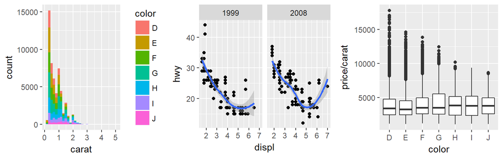

```r
q1 = qplot(carat, data=diamonds, geom="histogram", fill=color)
q2 = qplot(displ, hwy, data=mpg, facets=.~year, geom=c("point", "smooth"))
q3 = qplot(color, price/carat, data=diamonds, geom="boxplot")
grid.arrange(q1, q2, q3, ncol=3)
```

## 1.3 Research question

The author investigated the possibility of providing accessibility to ggplot2 graphics by extending BrailleR’s VI and MakeAccessibleSVG functionality to the graphics produced using ggplot2. As initial investigations were promising, an implementation was attempted in order to demonstrate the potential of this approach and to identify any likely barriers to further development.

## 1.4 Structure of this dissertation

Chapter 2 below describes related research on accessibility of graphs and similar visual content. Chapter 3 presents the results in the form of the author’s contribution to the BrailleR package, demonstrated with sample graphs and their corresponding descriptions. Chapter 4 provides more detail of the developed system’s architecture and its benefits, and other detailed design aspects. Chapter 5 explores limitations of the developed system and their implication for future development. Chapter 6 outlines potential future research directions along with some concluding discussion.

This dissertation is written using R Markdown and is intended to be output primarily as an HTML document, which is more accessible than pdf format for many screen readers. All embedded graphs and associated VI output are generated by “knitting” the R Markdown document, so the output is seen exactly as it appears to the user.

# 2 Related research

The research literature describes a number of approaches to conveying graphical information for blind users, but there is relatively little that is available outside the research arena. Most systems are aimed at describing graphics produced by sighted people – few aim to support production of graphics by blind users.

A variety of technologies are available for blind people to access information that sighted people would consume visually. Screen readers read aloud the text from a web browser or other application display. Braille displays use movable pins to display a line of braille text in physical format. Embossers and heat-sensitive paper are available to create tactile diagrams using raised paper. There is also research into haptic and sonification interfaces, as described below. All of these technologies have value and many blind people use a combination of them. Erhardt and Shuman’s description of teaching statistics to a blind student(Erhardt and Shuman 2015) gives a good impression of the typical use of multiple technologies to accomplish the student’s learning objectives.

Screen readers have some clear advantages. Braille displays are expensive and still require a screen reader to identify the text(Godfrey and Loots 2014). Embossing and similar techniques can also be expensive and time-consuming, and may require assistance from sighted people. Screen readers are relatively inexpensive technology and widely adopted. For this reason, many systems focus on describing graphics in textual format which can then be presented by the screen reader. For creation of statistical graphics, this allows the user to easily experiment, with immediate feedback, to achieve the desired graphic, just as a sighted user would typically do.

## 2.1 Text description of statistical graphics

Research on generating natural language descriptions of data trends or graphics has a long history spanning more than 3 decades. An early paper(Kukich 1983) described a system aiming to generate stock reports from a database of stock quotes. Other early work aimed to produce captions for graphics(Mittal et al. 1998; Corio and Lapalme 1999), or graphics and captions together based on the user’s intent(Fasciano and Lapalme 1996). While this research wasn’t targeted at the blind community, it explored similar issues around describing graphical content using natural language.

The SIGHT system(Elzer et al. 2007; Demir et al. 2010) is a browser add-on which aims to extract the information content of bar graphs present on web pages. The authors describe the difficulty blind readers (especially those who are congenitally blind) may have in building a “mental map” of a graphic – so their descriptions aim to convey the informational intent of the graph at a somewhat higher level. An example of the description their system produces is “This bar chart titled ‘The notebook spiral’ shows that the dollar value of average laptop prices fell from 2000 to 2003 and then falls more slowly until 2007.”

Ferres et al(Ferres et al. 2007) describe their iGraph-Lite system aimed at providing accessibility to graphics published by Statistics Canada. Their system provides a combination of a fixed textual description of the graph, along with an interactive facility to explore the graph detail. They comment that “unlike SIGHT, iGraph-Lite does not attempt to automatically infer and communicate the graph’s intended message to the user”, preferring instead to let the user interpret the meaning based on their own information needs, via their own interactive exploration of the graph.

BrailleR is targeted at users of statistical software, who have access to the data to explore it in various ways. As such, an approach that encourages data exploration could be argued to be more appropriate for BrailleR as well, rather than one that attempts to extract meaning for the user.

In earlier work by Ferres and others(Ferres et al. 2006), a study was performed involving blind and vision-impaired participants, to identify what information they wished to receive in order to understand the contents of a graph. The top three requests from participants were as follows:

- to hear the purpose, type and title (main and axes) of the graph first
- to describe the graph point-by-point (while acknowledging that this might only be useful for simple graphs)
- to describe the general trend and then the details

The UK Association for Accessible Formats develops standards and provides advice related to accessible alternatives to printed information, including general principles for accessible images as well as specific standards for describing charts and graphics(UK Association for Accessible Formats 2017). This is also discussed in a paper by Godfrey and Loots on teaching statistics to blind students (Godfrey and Loots 2015).

Depending on the situation and the purpose of a graphic, the blind user’s information needs vary. If the graph is produced by a sighted person to convey some information (e.g. “this value has been rising slowly but has now peaked”), the blind user may simply need to have that same information conveyed in another format. They may not have any concern for how the graph looks (e.g. whether it is a bar or line graph). This can also be true if the blind user is producing the graph for their own data analysis purposes – e.g. a statistics student examining a residual plot. However, blind users also need to be able to produce graphs for sighted people - such as students submitting assignments or scientists and professionals communicating with clients or colleagues. In these cases the blind user does need an understanding of whether the graph successfully conveys the intended information, and something about its aesthetics. In order to effectively be a graph producer, blind users need to also be able to consume those graphs, to confirm what has been produced. Godfrey and Loots(Godfrey and Loots 2015), as part of an overall exploration of teaching statistics to blind students, explore this idea of those students as both producers and consumers of statistical graphics. Of course the ability of blind users to understand some visual concepts such as color will vary depending on their background, but one should not assume they have no interest in these aspects.

## 2.2 Haptic and sonification systems

A team at the University of Glasgow(Ramloll et al. 2000; Yu, Kangas, and Brewster 2003; McGookin and Brewster 2006) have developed systems using haptic displays and auditory cues to allow blind users to explore and edit simple graphs. They convert line or bar graphs to virtual surfaces that can be explored with the haptic device, which also providing various forms of auditory feedback, including using pitch and apparent sound direction to convey information about the graph shape.

The SAS graphics accelerator(SAS Institute Inc 2017) also provides a sonification function for exploring graphs, using pitch to convey vertical position and sound directionality to convey horizontal position. There is also an R package “sonify”(Siegert and Williams 2017) for doing data sonification.

Haptic and sonified displays are typically focused on the “content” of the graph – the data being plotted and what information it conveys. But blind users also need access to what might be called the *framework* – the axes, annotations, panels, and aesthetics of the plot. In fact a good understanding of the framework is probably where the blind user needs to start – what kind of graph is this, what variables are involved, what hints (e.g. title, labels) are given about what information I might find here. This focus on framework first was also reflected in Ferres et al’s findings mentioned earlier.(Ferres et al. 2006) Likewise the blind user creating a graph needs to confirm that the structure of the created graph matches what was intended. Even when haptic or sonified displays are used, textual description is likely to be required for conveying this graphic framework.

## 2.3 Interactive exploration of graphical artifacts

When sighted people examine a graph or diagram, their visual focus moves from one portion of the graphic to another, possibly returning later to more fully examine a given component. Similarly, several systems have aimed to enable blind users to interactively explore various sorts of visual diagrams.

The PLUMB system(Calder et al. 2006) allows users to navigate simple connected graphs (vertices and edges) through a combination of speech and auditory feedback as the user navigates around the graph. The MathTalk system(Stevens and Edwards 1994) supports understanding of math equations through interactive exploration. Bennett (Bennett 2002) compare hierarchical vs connection-based navigation when exploring central heating system diagrams. As mentioned above, the iGraph-Lite system for describing Statistics Canada output also supports interactive exploration.

Several different groups(Brown, Pettifer, and Stevens 2003; Fartaria et al. 2013; Sorge, Lee, and Wilkinson 2015) have developed accessible molecule browsers that allow interactive investigation of molecular diagrams. Volker Sorge from the team at the University of Birmingham was approached by the author of BrailleR, leading to his involvement in the development of the BrailleR function MakeAccessibleSVG(Fitzpatrick, Godfrey, and Sorge 2017) as described above.

## 2.4 Accessibility of statistical software

Software can vary greatly in how well it integrates with screen readers, and in other aspects of its usability by blind users. Godfrey and Loots(Godfrey and Loots 2014) provide a good summary of the accessibility of popular statistical software including SAS, R, SPSS, and Minitab (at least as at 2014). Overall, R and SAS were found to provide the best accessibility for blind users.

More recently, the SAS graphics accelerator has been released. As described on the SAS Institute website(SAS Institute Inc 2017), it provides both text descriptions and the sonification interface mentioned earlier for exploring SAS graphics.

Godfrey(Godfrey 2013) describes in more detail methods for making R accessible, and introduces the BrailleR package.

# 3 Results

The contribution of this project was to explore the extension of the BrailleR graphics exploration functionality to graphics produced using ggplot2. It was found that ggplot2 graphics are generally amenable to extraction of information to support text-based reporting and exploration. This was demonstrated through development of an extension to the BrailleR package, which comprised the following components:

- a VI.ggplot method, for describing ggplot objects (this is the primary output)
- a pilot MakeAccessibleSVG method for exploring histograms created using ggplot2
- filtering functions VIgrep and VIsort to further process the VI.ggplot output

This additional functionality has been incorporated into the official BrailleR source code repository at https://github.com/ajrgodfrey/BrailleR, for inclusion in an upcoming release of BrailleR.

In the remainder of this chapter each of these methods/functions and their output will be demonstrated, as “black boxes”. Later, in the “implementation” chapter, the design decisions and other implementation details will be discussed.

## 3.1 VI.ggplot

A VI method has been developed which can produce fairly detailed descriptions for a wide variety of ggplot2 graphics.

Returning to the 3 example plots from earlier, each plot is shown below in Figure 5 followed by its corresponding VI output.

Note that for the first two plots, individual item detail is not shown because of the large number of items. The “threshold” parameter for specifying the amount of detail to report is discussed below. Plot 3 below does include the detail for each box plot, and further examples demonstrating detail reporting for other graph types can be found later and in the appendix.

**Figure 5: example graphs with their VI descriptions**

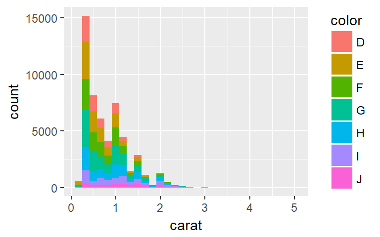

```r
(q1 = qplot(carat, data=diamonds, geom="histogram", fill=color))
```

```r
VI(q1)
```

```
This is an untitled chart with no subtitle or caption.
It has x-axis 'carat' with labels 0, 1, 2, 3, 4 and 5.
It has y-axis 'count' with labels 0, 5000, 10000 and 15000.
There is a legend indicating that fill is used to represent color, with 7 levels:
D represented by fill #F8766D,
E represented by fill #C49A00,
F represented by fill #53B400,
G represented by fill #00C094,
H represented by fill #00B6EB,
I represented by fill #A58AFF and
J represented by fill #FB61D7.
The chart is a bar chart containing 210 vertical bars.
```

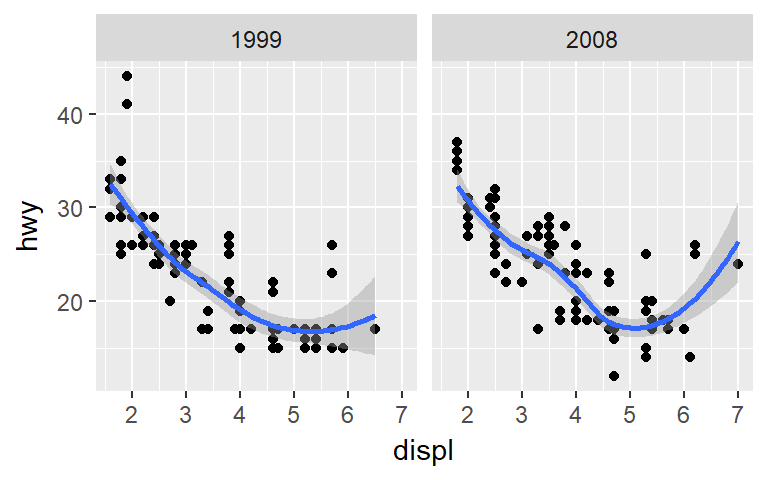

```r
(q2 = qplot(displ, hwy, data=mpg, facets=.~year, geom=c("point", "smooth")))
```

```r
VI(q2)
```

```
This is an untitled chart with no subtitle or caption.
The chart is comprised of 2 panels containing sub-charts, arranged horizontally.
The panels represent different values of year.
Each sub-chart has x-axis 'displ' with labels 2, 3, 4, 5, 6 and 7.
Each sub-chart has y-axis 'hwy' with labels 20, 30 and 40.
Each sub-chart has 2 layers.
Panel 1 represents data for year = 1999.
Layer 1 of panel 1 is a set of 117 points.
Layer 2 of panel 1 is a smoothed curve using method 'auto' with confidence intervals.
Panel 2 represents data for year = 2008.
Layer 1 of panel 2 is a set of 117 points.
Layer 2 of panel 2 is a smoothed curve using method 'auto' with confidence intervals.
```

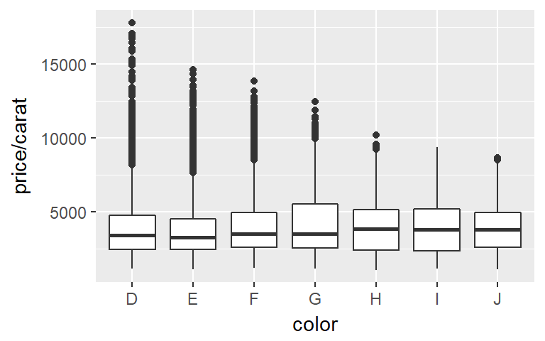

```r
(q3 = qplot(color, price/carat, data=diamonds, geom="boxplot"))
```

```r
VI(q3)
```

```
This is an untitled chart with no subtitle or caption.
It has x-axis 'color' with labels D, E, F, G, H, I and J.
It has y-axis 'price/carat' with labels 5000, 10000 and 15000.
The chart is a boxplot comprised of 7 boxes with whiskers.
There is a box at x=D.
It has median 3410.53. The box goes from 2455 to 4749.31, and the whiskers extend to 1128.12 and 8183.33.
There are 338 outliers for this boxplot.
There is a box at x=E.
It has median 3253.66. The box goes from 2430.3 to 4508.41, and the whiskers extend to 1078.12 and 7616.39.
There are 593 outliers for this boxplot.
There is a box at x=F.
It has median 3494.32. The box goes from 2587.1 to 4947.22, and the whiskers extend to 1168 and 8477.5.
There are 585 outliers for this boxplot.
There is a box at x=G.
It has median 3490.38. The box goes from 2538.24 to 5500, and the whiskers extend to 1139.02 and 9937.2.
There are 119 outliers for this boxplot.
There is a box at x=H.
It has median 3818.89. The box goes from 2396.88 to 5127.28, and the whiskers extend to 1051.16 and 9220.
There are 13 outliers for this boxplot.
There is a box at x=I.
It has median 3779.74. The box goes from 2344.65 to 5196.75, and the whiskers extend to 1151.72 and 9397.5.
There are 0 outliers for this boxplot.
There is a box at x=J.
It has median 3780. The box goes from 2562.87 to 4927.95, and the whiskers extend to 1080.65 and 8426.13.
There are 3 outliers for this boxplot.
```

A large number of different “geoms” (i.e. object types) are provided by ggplot2. The implemented method is currently able to report on the following geom types:

- point - which draws objects (dots or other shapes) at specified (x, y) positions
- line - which draws one or more lines connecting a series of points
- histogram - which creates a bar chart summarising the number of occurrences of different values of some x variable, potentially broken down into groups by some additional variable(s).
- boxplot - which produces a box-and-whisker plot summarising the distribution of a given variable, also potentially broken down into groups by some additional variable(s)
- hline - which draws one or more horizontal lines. This is typically used as an additional layer with another geom type, e.g. to represent some threshold value.
- smooth - which fits a smoothed curve to a set of (x, y) coordinates. This is typically used as an additional layer with the “point” geom

This set was chosen because it allows many popular plot types to be represented. It also includes both individual and summary geoms, which vary in the amount and type of information they convey. As such it should both demonstrate the value of working with ggplot2 and bring to light any likely issues.

For all plot types the following details are able to be reported:

- titles, subtitles and captions
- if faceted, the number of facets, how they’re laid out, and what variable(s) are varying
- axis labels and tick marks (reported separately for each facet if they vary)
- what geom is present. If there are multiple layers, each layer’s geom is described
- information about guides (legends) - including what variable is represented and the aesthetic to which it is mapped
- individual data points if they number less than a specified threshold. The values reported vary by geom:
  - x and y positions for points
  - x and y positions for the points on each line, for lines
  - y position for horizontal lines
  - x position and width, and upper and lower bounds for bars
  - x position, upper and lower box and whisker bounds, and number of outliers for box plots
  - method and whether confidence intervals are displayed for the “smooth” geom
- Aesthetics used to represent variable values (more on this below)

In ggplot2 various aesthetics can be used to represent values in the data – for example, variables can be represented by colour, point shape or size, or line type. When an aesthetic is used to represent a variable, this is detailed by VI.ggplot when describing the legend, as well as when reporting the item detail. Figure 6 shows an example.

**Figure 6: Reporting of aesthetics**

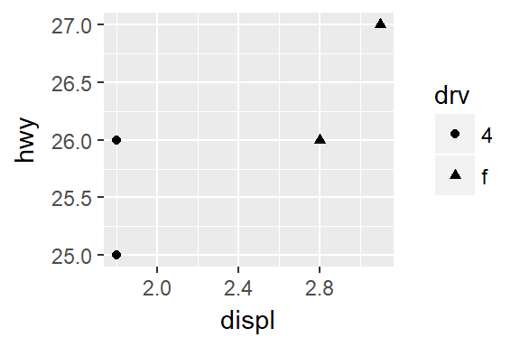

```r
(q = qplot(data=mpg[6:9,], displ, hwy, shape=drv))
```

```r
VI(q)
```

```
This is an untitled chart with no subtitle or caption.
It has x-axis 'displ' with labels 2.0, 2.4 and 2.8.
It has y-axis 'hwy' with labels 25.0, 25.5, 26.0, 26.5 and 27.0.
There is a legend indicating that shape is used to represent drv, with 2 levels:
4 represented by shape solid circle and
f represented by shape solid triangle.
The chart is a set of 4 points.
The points are at:
(2.8, 26) shape solid triangle which maps to drv = f,
(3.1, 27) shape solid triangle which maps to drv = f,
(1.8, 26) shape solid circle which maps to drv = 4 and
(1.8, 25) shape solid circle which maps to drv = 4
```

Difficulties and limitations in reporting of aesthetics will be discussed in subsequent chapters.

Several additional example graphs and their output, demonstrating more of the method’s functionality, are shown in Appendix 1.

## 3.2 MakeAccessibleSVG.ggplot

To demonstrate the feasibility of supporting interactive exploration of ggplot objects, a limited implementation of a MakeAccessibleSVG.ggplot method was developed. For this proof-of-concept, the functionality of MakeAccessibleSVG.histogram was replicated, for similar histograms produced using ggplot2 rather than base R graphics. The developed method is able to correctly process the same type of histograms supported by MakeAccessibleSVG.histogram - namely, those representing uni-variate data with a continuous x axis.

An example plot which can be interactively explored is shown in Figure 7:

**Figure 7: Histogram produced by ggplot2**

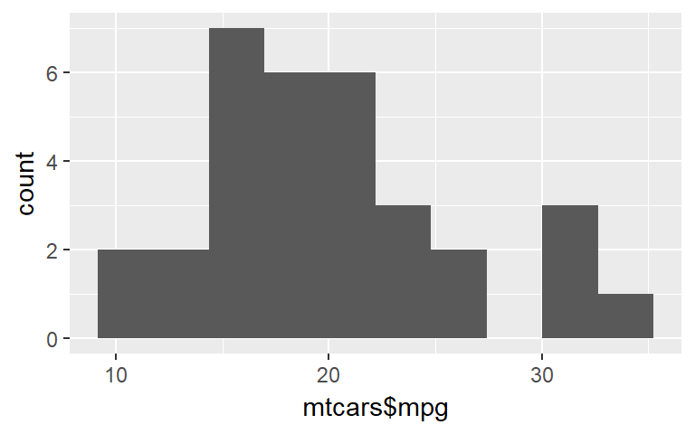

```r
qplot(mtcars$mpg, bins=10)
```

The MakeAccessibleSVG.ggplot method operates very similarly to the previously existing MakeAccessibleSVG method for base R histograms. In fact exactly the same web page source and JavaScript is used, but the SVG displayed has been produced from the ggplot2 graphic and the XML has been built accordingly. Once the web page has opened, the user is able to navigate interactively to hear descriptions of the individual components of the graphic, while the SVG display at the top of the page highlights and zooms in on the component being described.

An example of the descriptive text that might be displayed as the user interactively navigates the above graphic is shown below in Figure 8. The initial line is shown when the web page opens, and subsequent lines are displayed as the result of user navigation.

**Figure 8: Sample descriptive text from MakeAccessibleSVG.ggplot**

```
Chart with x-axis mtcars$mpg and y-axis count
x axis: mtcars$mpg with values from 10 to 30
Label mtcars$mpg
x axis: mtcars$mpg with values from 10 to 30
y axis: count with values from 0 to 6
Histogram with 10 bars
Bar 1 between x values 9.139 and 11.75 with y value 2 and density 0.0239
Bar 2 between x values 11.75 and 14.36 with y value 2 and density 0.0239
```

It is rather difficult to show the operation of MakeAccessibleSVG in a document. Readers are encouraged to try it out for themselves by downloading the developed software from the BrailleR github repository at https://github.com/ajrgodfrey/BrailleR. Implementation details will be discussed in the next chapter.

Based on the findings of this investigation, it would appear possible in theory to implement MakeAccessibleSVG for any ggplot object that can be handled by VI.ggplot. The lack of further progress in this area was due to time constraints, not any deeper impediments that have yet been discovered. The functionality to collect the necessary information about the graph and organise it in a hierarchical structure is already in place for VI.ggplot. The navigation in MakeAccessibleSVG is also hierarchical and so there is a natural alignment between the two.

## 3.3 Filtering functions

The VI.ggplot method returns an object containing a hierarchical representation of the graph structure, as well as the text output. This supports the creation of functions that further filter or process the output. Two very simple filtering functions were created, both as demonstrations of the concept and because they were felt to be legitimately useful to BrailleR users.

VIgrep is a text filter which simply limits the text output to those lines matching some specified pattern. An example usage is shown below in Figure 9, pulling out only those lines of the VI output that discuss a plot axis.

**Figure 9: Usage of VIgrep**

```r
VIgrep("axis", VI(qplot(data=diamonds, clarity, color)))
```

```
It has x-axis 'clarity' with labels I1, SI2, SI1, VS2, VS1, VVS2, VVS1 and IF.
It has y-axis 'color' with labels D, E, F, G, H, I and J.
```

One usage of VIgrep could be to focus on specific data items. This need would probably be better served by an object filter, but in the absence of such a function, VIgrep can be used. This is demonstrated below in Figure 10: a graphic is described using VI, but the data detail is not shown because the number of points exceeds the default threshold. Subsequently a higher threshold is set, with VIgrep used to limit output to only those points of interest (here, 6-cylinder cars only).

**Figure 10: Selecting a subset of the data using VIgrep**

```r
# First get the high level description.
VI(qplot(data=mtcars, disp, mpg, shape=factor(cyl)))
```

```
This is an untitled chart with no subtitle or caption.
It has x-axis 'disp' with labels 100, 200, 300 and 400.
It has y-axis 'mpg' with labels 10, 15, 20, 25, 30 and 35.
There is a legend indicating that shape is used to represent factor(cyl), with 3 levels:
4 represented by shape solid circle,
6 represented by shape solid triangle and
8 represented by shape solid square.
The chart is a set of 32 points.
```

```r
# We are only interested in the 6-cylinder cars.
# Set a high enough threshold to print all data rows, then
# select only those of interest using VIgrep, now that we
# know these are represented by triangles.

VIgrep("triangle",
       VI(qplot(data=mtcars, disp, mpg, shape=factor(cyl)), threshold = 100))
```

```
6 represented by shape solid triangle and
(160, 21) shape solid triangle which maps to factor(cyl) = 6,
(160, 21) shape solid triangle which maps to factor(cyl) = 6,
(258, 21.4) shape solid triangle which maps to factor(cyl) = 6,
(225, 18.1) shape solid triangle which maps to factor(cyl) = 6,
(167.6, 19.2) shape solid triangle which maps to factor(cyl) = 6,
(167.6, 17.8) shape solid triangle which maps to factor(cyl) = 6,
(145, 19.7) shape solid triangle which maps to factor(cyl) = 6,
```

VIsort is an object filter (currently only implement for objects of type “point” i.e. scatter plots) which sorts the data points according to the x or y value, to change the order in which they will be reported in the printed output.

These functions are both quite simple and their functionality could be achieved in other ways, but they illustrate a potentially broader class of filter that could be developed.

# 4 Implementation

This chapter will describe the architecture of the developed system, the use of templating, and other implementation-level details.

## 4.1 Architecture

In the development process for VI.ggplot, it was very clear that we don’t have all the answers about how best to present the information contained a in graphic to the blind user – and in fact, that there is not likely to be a single right answer. Users of the software will differ in their familiarity with visual graphics (influenced in part by whether they were blind from birth) and their level of statistical knowledge. Their purpose in producing or examining graphics will also have a large impact on what information they find relevant, as previously discussed. A statistics student examining a residuals plot will not be particularly interested in the aesthetic characteristics of the plot, but a researcher producing a graph for publication will be.

For this reason, it was seen as important that the system design provide as much flexibility and extensibility as possible. Several aspects of the developed design furthered that goal:

- Returning a structured object amenable to further examination or filtering
- Use of a templating system which separates the information presentation from the extraction logic

**Figure 11: Flow diagram showing steps involved in VI.ggplot processing**

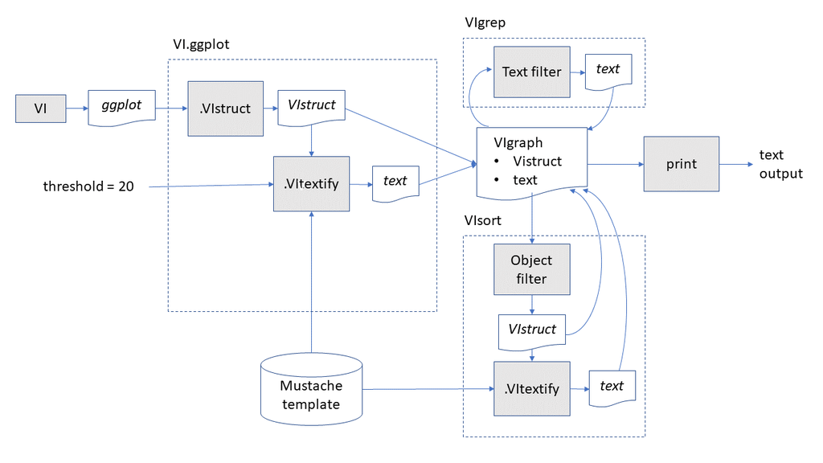

Figure 11 shows the high-level process flow of the developed system, including optional filtering steps. The object produced by ggplot2 is processed by the .VIstruct function to extract the relevant information about the graphic, and this information is stored in an object of class VIstruct. This object is then passed to .VItextify which creates the text description of the object based on a template. The behaviour of .VItextify can be modified by specifying a different mustache template to use, or by modifying the threshold for listing individual data points. Both the VIstruct object and the text are returned in the form of a VIgraph object. The print function for the VIgraph object simply prints the text component. The templating system will be described in more detail below.

Optionally, the VIgraph object can be further processed, either by a text filter, or by an object filter which modifies the VIstruct object in some way and then recreates the text output accordingly. A variety of different filters of either type can be envisioned. The VIgrep and VIsort functions discussed above are simple example filtering functions – VIgrep is a text filter processing only the text output, while VIsort is an object filter, recreating the text after modifying the object.

The pilot MakeAccessibleSVG.ggplot method also calls the .VIstruct function to create the VIstruct object. The contents of this object then are used in constructing the XML document that drives the interactive navigation. The method does not currently use .VItextify in creating its text descriptions, but it is foreseen that this could be desirable at some future stage.

## 4.2 Information extraction from ggplot objects

An advantage of ggplot2 is that it gives access to its “inner workings” at a number of levels. This can best be described by examining how the ggplot2 package itself operates to produce a graphic.

Firstly, the qplot or ggplot function itself constructs an object which contains information about the requested plot, as well as the raw data for its construction. This object is returned with class “ggplot”.

The “+” operator can be used to add additional layers or to modify the scale, theme, coordinate system, or faceting of the plot. Any of these actions modify the ggplot object with the new specifications.

A ggplot2 graphic is actually drawn by the print.ggplot function. That print function at its heart comprises the following logic (where x is the object returned by the ggplot function call):

```
  data <- ggplot_build(x)
  gtable <- ggplot_gtable(data)
  grid.draw(gtable)
```

These functions are exported from the ggplot2 package so are accessible outside it. The ggplot_build function is particularly useful as it performs a significant amount of the processing needed to construct the graphic, and returns the result of that processing in a new object (named “data” in the code fragment above – it will be referred to herein as the ggplot_build object). The software developed as part of this project utilises ggplot_build in order to create this object, which is referenced to extract information about the graphic.

In the code above, the ggplot_gtable function completes the processing needed to produce the plot, resulting in a “gtable” which is a collection of “grobs”. Grid is designed such that those lower level objects are accessible to query or modification. While not calling ggplot_gtable directly, the MakeAccessibleSVG.ggplot method does access the created grid objects through use of the “grid.grep()” command. This is used to identify the names of the various component grid objects that will end up in the SVG file – more on this below.

Each of the geom types supported by ggplot2 has a set of aesthetics that can be associated with it – things such as line and fill colours, point shapes, line types such as dashed or dotted, line width, and alpha (which specifies the transparency level of the item). These aesthetic values are stored with the data in the ggplot_build object, so are able to be extracted and reported on by the VI.ggplot method (and potentially by MakeAccessibleSVG.ggplot though this isn’t currently supported).

Similarly, each geom has a default “statistic” associated with it. The point type, for example, uses the identity statistic, which simply means that each input data item is represented by an individual point. Histograms, on the other hand, by default use a summary statistic. The data is grouped into bins according to the x values, and counts for each bin are what is represented on the y axis. The object created by the ggplot_build function stores the processed data, after the appropriate statistic has been applied, and this is the data used in creating the plot description. Any approach that would require referencing the original raw data has been avoided, since it would then be necessary to replicate the functionality of the statistic function being used. Only the processed data is referenced. This differs from the processing done by some of the existing BrailleR functions, which need to perform their own processing on the raw data due to limitations in what information is available in the object returned by the graphics functions.

## 4.3 The VIstruct object

One very flexible aspect of ggplot2 is its support for layered and faceted plots. Layered plots are those where multiple geoms (of the same or different types) are overlaid on the same axes. This facility has already been mentioned in reference to the hline and smooth geoms, but any geoms can be layered, producing potentially novel and arbitrarily complex plots. Faceted plots include multiple panels. Each panel contains a similar plot, but covering a different subset of the raw data. The second ggplot2 example shown above in the introduction is a faceted plot, faceting the data on the “year” variable.

The VIstruct object developed in this work supports representation of arbitrarily faceted and layered plots. It contains a tree structure, with one or more facets containing within them one or more layers, each of which contains detailed data. At the same time, some information (such as the plot title and what variables are on each axis) are consistent across all the facets and layers, and so are stored at the top level of the object. This structure is mirrored in the textual description of the plot produced by VI, with the consistent items described first, followed by each facet in turn, within which each layer and its data is described. While MakeAccessibleSVG functionality hasn’t been developed for faceted charts, one would expect the same hierarchical structure to apply. MakeAccessibleSVG navigation is already hierarchical, and one would expect the facets to sit at a higher layer in the hierarchy, followed by the layers and then the data within them. In this way, the object structure supports the needs of both functions, even though the MakeAccessibleSVG functionality to use this is not yet developed.

## 4.4 Software development and testing

As is always the case in software development, it was important to ensure that the software for this implementation was carefully managed and that recent changes didn’t break functionality developed earlier.

The software was stored in github, in a repository forked from the BrailleR repository. The author’s source repository for the project can be accessed at https://github.com/dewarren/BrailleR. This github repository was integrated with Travis CI(Travis CI, GmbH 2017). Travis CI is a continuous integration service that allows software on github to be automatically tested whenever a new version of the code is stored. Any test failures are notified to the developer. While local testing was also done, this provided an additional level of confidence. One particular benefit was that it was possible to test in a Linux environment through Travis CI, while local development was on a Windows PC.

There was an existing test script in the Braille package which creates a selection of ggplot2 graphics (pulled from Wickham’s ggplot2 book(Wickham 2016)) and runs VI on them. Initially there was just a stub VI.ggplot function existing, so there was no meaningful output produced. This set of test cases was a useful touchstone, as improvement could be seen in the method’s output for these graphs as work progressed. The R package facility for automatic testing was also used. R has a “check” facility that performs various integrity checks on a package under development. The package developer can include a “tests” directory in the package, containing a set of scripts and stored output from those scripts. When a “check” is performed, those scripts will be run and the output compared against what it stored. This allows quick verification that a change has not broken existing code. This testing was introduced fairly late in the development process, and in retrospect it would have been useful earlier.

Documentation in the form of man pages was developed for the new functions and incorporated into the package.

Because of the developed software’s heavy reliance on the object created by ggplot_build, it is vulnerable to changes in this object with new versions of the ggplot2 package. This risk has been reduced by isolating all references to this object in small functions, intended, as much as possible, to extract a single fact about the plot. In this way it is hoped that any future changes to the ggplot_build object will only necessitate changes to those functions and not the broader processing logic. The benefits of this were observed when the package was (inadvertently) tested against the latest development version of ggplot2 rather than the current production release. It was discovered that two changes had been made to the ggplot_build structure in the latest version, which necessitated corresponding changes to the data extraction functions. In each case, one line of code was affected, and both the old and new formats are now catered for. If this is indicative of the level of impact that might be expected with future ggplot2 versions then it should be quite manageable to update the package accordingly.

No testing has been done with versions of ggplot2 prior to the current published version of 2.2.1 so it is not possible to comment on compatibility with earlier versions.

## 4.5 Templating

Early in the project it was identified that it would be desirable to isolate the developed programming logic from the exact formatting of the text output. A decision was made to investigate a templating system, which would have a number of benefits:

- Enable changes to the text descriptions based on user feedback, without requiring software changes
- Enable creation of alternative templates for different purposes. For example, some users will be interested in the actual plot aesthetics (e.g. shape or colour) while others would prefer that only the variable mapping be reported.
- Enable advanced users to create their own templates
- Enable the creation of templates for other languages

One option considered for the templating was XSLT. It is a very powerful transformation language and could definitely meet the project’s needs. There is an R package “xslt” that supports it. However, it seemed a very “heavy” option. The “xml” package would also be needed to convert R objects into XML before they could be processed by “xslt”. Also, given the complexity of XSLT it could discourage users unfamiliar with it from creating their own templates.

Further investigation identified “mustache” templates as a better option. Mustache is a lighter-weight templating language and is supported by the R package “whisker”. As implemented in the “whisker” package, mustache templates can operate directly on R objects without the need for any initial transformation.

This templating system is called “mustache” because of its extensive use of curly brackets or braces (“{”). It has a very limited set of operators:

- “{{x}}” inserts the value of the variable x at the given location in the text
- “{{#x}}Text{{/x}}” inserts one copy of the enclosed content (here, “Text”) for each item in the list x (and none if x does not exist)
- “{{^x}}Text{{/x}}” inserts the enclosed content (here, “Text”) only if variable x is not defined

Together these effectively support substitution, simple if/then/else structures based on the existence of an object, and simple looping over the items of a list. Items to be repeated need to be stored in lists, and it is not possible to act based on the value of a variable, only its presence or absence.

These limitations imposed some requirements that wouldn’t otherwise have been present for the VIstruct data structure. It was decided to build the data structure in the way that seemed most logical independent of mustache’s limitations, and then implement those additional requirements as a pre-processing step before template matching. In this way, flexibility is retained to switch to XSLT or another templating system at some stage in the future and easily discard these then-unneeded additional steps.

Examples of the pre-processing required include:

- Variables in a data frame need to be converted into a list in order to be reported at a detailed level. For efficiency reasons this step is only performed if the number of items is lower than the detailed reporting threshold, as otherwise the list will not be needed.
- It is not straightforward in mustache to create the natural language construct “a, b and c” from the list (a, b, c). A small function was built to insert the needed separator into the list so that it can then be included by mustache.
- Any spacing or line breaks in the mustache template are copied directly to the output. This tends to make the template very dense and unreadable. Instead, line breaks were inserted freely in the template for readability, and the characters “<br>” were inserted where a line break was actually desired in the output. Before performing the template matching, a step is performed to remove all the embedded line breaks, and after template matching a final step replaces all occurrences of “<br>” with line breaks. In this way the templates can much more readable.

Several fragments of the default mustache template developed for VI.ggplot are shown below in Figure 12 for illustrative purposes:

**Figure 12: mustache template fragments**

```
{{#title}}This chart has title '{{title}}'.<br>{{/title}}
{{^title}}This chart is untitled.<br>{{/title}}
...
In this panel, x-axis '{{xlabel}}' has labels {{#xtickitems}}{{label}}{{sep}}{{/xtickitems}}.<br>
...
{{#colour}}This line has colour {{colour}}{{#colourmap}} which maps to {{colourlabel}} = {{colourmap}}{{/colourmap}}.<br>{{/colour}}
...
```

The author’s initial hope with use of the mustache templating system was that non-programmers could feel comfortable to modify the templates to create their own custom ones. In retrospect, given the complexity of the templates, even using mustache’s relatively simple syntax, this may be unlikely. The templating approach nonetheless provides other benefits by separating the grammatical formatting from the information extraction, and by potentially supporting alternative templates being made available to focus on various aspects of the graph or to permit reporting in other languages.

The mustache processing logic has been developed to enable translating one large object or a list of small objects in each call. When used by the “VI” function, one large text object (broken into lines) is produced. The templating system is not currently used for MakeAccessibleSVG, but this could be desirable at some future point. In that case it would likely be desirable to translate the text for each component individually.

Documentation has been included within the package of the structure of the VIstruct object, to support the development of alternate templates. The README.md file within the whisker directory of the install details the full hierarchical structure of the created object, making clear what variables are available for use by the mustache template.

## 4.6 Reporting of data item detail

The VI.ggplot report always begins by describing the basic framework on the graphic (annotations, axes, legends, facets, and layers). This is followed by the detail for each panel/layer combination.

Obviously it is not useful to list the (x, y) coordinates for every point on a scatter plot containing 5000 points. A “threshold” parameter is provided for VI.ggplot, which has a default value of 10. If the number of individual data items (e.g. points, bars, lines, or points on a line) is less than or equal to the threshold value then the full detail will be reported. Otherwise the software will simply report “The chart is a set of 5000 points”.

It should be noted that when coupled with the use of the VIgrep function, specifying even a very large threshold value could at times be useful, as the resulting detail could be filtered by VIgrep to a manageable volume.

In building the detail reporting, the software makes use of the plot data detail stored in the ggplot_build object for each layer. This data has already been processed in a variety of ways which may mean it doesn’t always correspond to what the user would like reported.

There are two types of variable mappings that may be present in a ggplot2 graphic – positional mapping (mapping variables on the x and y axes) and aesthetic mapping (mapping variables to colours, shapes, line types, and the like). Each of these will be discussed in turn.

### 4.6.1 Positional detail

When variables are mapped to x and y positions in the graphic, they can be altered in the following ways, reflected in how they are stored in the ggplot_build object:

- Categorical variables can be mapped to an axis, with the values evenly spaced along the length of the axis. R has a data type “factor” for representing categorical variables, but in the ggplot_build object these x or y values are stored as simple integers, not as R factors. For example, if a variable taking values “auto” and “manual” is mapped onto the x axis, then the x-axis values will be stored in the ggplot_build object as 1 or 2. This is done to support jittering or positioning of items such as labels anywhere on the graph.
- The x and y positions may be transformed, e.g. to create log-scale axes. In this case the transformed value (e.g. log(x)) is stored rather than the original value
- A “position” adjustment may be applied. For example, points can be jittered, and multiple bars at the same x position may be stacked, or may be “dodged” to appear next to each other on the x axis. Position adjustments can be applied to factor variables, in which case the value stored is a real number, reflecting the appropriate modification to the integer corresponding to the factor level.

In all of these cases, the axis will be labelled with the original, non-altered values and this is presumably what the user would ideally like to have reported.

The information stored in the “scales” portion of the ggplot_build object is used by the VI.ggplot method to remap the data to the original values whenever possible:

- When the position variable is a factor, the factor levels are stored, so it is possible to map the integers back to the factor levels for reporting.
- When the data is transformed, the scale object makes an inverse function available, which can be used to transform the value back to the original scale
- However, a method has not yet been developed to undo jittering or other position adjustments. Jittered points are reported at their jittered position, and stacked or dodged items are reported at their adjusted positions. This also means that when the modified axis is a categorical axis, the values are not mapped back to the original categories but are reported as real number values. This is not ideal, and could be an area for future improvement.

There are cases where data is present in the ggplot_build plot data yet does not appear in the graphic. This can occur when the variable mapped to the x or y position has value “NA”. It can also happen when plot limits have been set. The ggplot2 functions provide a number of different syntaxes for setting bounds on the x or y values that should appear in the plot. The axes will be constructed accordingly, and values falling outside those limits will not appear. In both these cases, the VI method correctly recognizes that those points won’t be plotted and does not report on them.

### 4.6.2 Aesthetic detail

When variables are mapped to aesthetics, it is the aesthetic value that is stored in the ggplot_build object:

- colours are stored in hexadecimal format representing the red/green/blue values e.g. #F8766D
- Size is stored in millimeters. (Size can define line thickness, or shape size)
- Line types may be stored as names (e.g. “solid”, “dashed”), as integers between 0 and 6, or as hexadecimal representations of the pen up/down sequence.
- Shapes may be represented by integer values from 0 to 25 representing the 25 standard shapes, characters in which case that character is plotted, or “.” to draw the smallest visible rectangle.
- Alpha (transparency) is stored as a value between zero and one.

Note that most often, the user will not have specified the specific aesthetic values to use, so they will be chosen from some default palette. For example, if the user specifies “colour=var1” and var1 has 3 values then by default the colours assigned will be #F8766D, #00BA38, and #619CFF which are approximately red, green, and blue. Similarly, if “linetype=var1” had been specified then line types of “solid”, “22” (which could be described as dotted), and “42” (which could be described as dashed) will be assigned.

For aesthetics one would ideally wish to be able to report the aesthetic as well as the value that it represents – i.e. to report something like “this point is red which corresponds to region = 1”. This is not always possible in the current implementation.

If the mapped variable has discrete levels, more information can be provided than if it is continuous. Figure 13 shows the output that is produced for an aesthetic (shape) mapped to a discrete variable (drv)

**Figure 13: output for an aesthetic mapped to a discrete variable**

```r
VI(qplot(data=mpg[7:9,], displ, hwy, shape=drv))
```

```
This is an untitled chart with no subtitle or caption.
It has x-axis 'displ' with labels 2.0, 2.4 and 2.8.
It has y-axis 'hwy' with labels 25.0, 25.5, 26.0, 26.5 and 27.0.
There is a legend indicating that shape is used to represent drv, with 2 levels:
4 represented by shape solid circle and
f represented by shape solid triangle.
The chart is a set of 3 points.
The points are at:
(3.1, 27) shape solid triangle which maps to drv = f,
(1.8, 26) shape solid circle which maps to drv = 4 and
(1.8, 25) shape solid circle which maps to drv = 4
```

For a continuous variable the reporting is less complete as seen in Figure 14 - the aesthetic value is reported in the detail section but not the variable value to which it maps:

**Figure 14: output for an aesthetic mapped to a continuous variable**

```r
VI(qplot(data=mtcars[6:8,], disp, mpg, alpha=hp))
```

```
This is an untitled chart with no subtitle or caption.
It has x-axis 'disp' with labels 150, 200, 250, 300 and 350.
It has y-axis 'mpg' with labels 15.0, 17.5, 20.0 and 22.5.
There is a legend indicating that alpha is used to represent hp, ranging from 62 represented by alpha 0.1 to 245 represented by alpha 1.
The chart is a set of 3 points.
The points are at:
(225, 18.1) alpha 0.31,
(360, 14.3) alpha 1 and
(146.7, 24.4) alpha 0.1
```

The aesthetics that can be used to map continuous variables are size, alpha and colour (either as a border or a fill). As alpha and size are simple numeric values, it should be possible to calculate the original value, but this isn’t currently done. It is less clear how to translate colours back to the original variable value.

The other difficulty in reporting aesthetics is to describe them in a meaningful way. A function has been created which encapsulates building a meaningful name for a given aesthetic value – this function is rudimentary and is an area for further work. The current behaviour for each aesthetic is as follows:

- Names have been defined for the 25 standard shapes and these are reported.
- The software directly reports the hex RGB values for colours
- Size is numeric and is reported directly in millimeters
- Alpha is numeric and is reported directly
- Line types is reported as-is, which can be a name (“dotted”), an integer index, or a hex pen-up/pen-down value such as “3131”

## 4.7 MakeAccessibleSVG.ggplot implementation

Implementation details for the MakeAccessibleSVG.ggplot method will now be discussed. The reader may recall that the web page constructed by MakeAccessibleSVG contains the following:

- an SVG representation of the graph
- A corresponding XML file which describes a hierarchical structure of the components of the SVG
- JavaScript which supports the interactivity, as described further below
- An html wrapper for the above components, including help text about the available navigation commands

The SVG graphic is created using the gridSVG function. Since ggplot2 graphics are built upon the grid graphics system, the use of gridSVG for this is straightforward and this functionality was already in place in the package. The JavaScript and html used is the same as that used for the other MakeAccessibleSVG methods already present in the package as well. Therefore the challenge in this project was to create appropriate XML to describe the hierarchical structure of the ggplot2 graphic.

There are two aspects to this:

- identifying the objects present in the graphic and organising them into a suitable hierarchical structure, and
- matching those objects to the names of the corresponding grid objects (and hence the corresponding objects in the SVG file)

As with the VI method, the developed MakeAccessibleSVG.ggplot method begins by creating the VIstruct object which captures the structure of the graph. This object is built with a hierarchical structure that naturally aligns to the hierarchical structure that would be desired for the MakeAccessibleSVG navigation. While functionality is very limited currently, mapping from this structure to the required XML structure for MakeAccessibleSVG should in principle be fairly straightforward for more complex graphics as well.

The greatest difficulty is in finding the names of the corresponding structures in the SVG object. These names need to be provided for the JavaScript to be able to highlight the relevant portions of the SVG as the user navigates interactively. Since the SVG is created using gridSVG, its structure matches that of the grid objects built by ggplot_gtable. The naming is predictable, except that random numeric suffixes are used to ensure uniqueness of object names. Sub-objects within a given object are sequentially numbered. So, the bars within a bar graph may have names such as “geom_rect.rect.2297.1.1”, “geom_rect.rect.2297.1.2”, and so on.

MakeAccessibleSVG.ggplot uses the grid.grep() function, which allows searching a grid object for components whose names match a given pattern. Since each type of component in the object structure corresponds to a known naming scheme, this allows location of the matching grid object. Two potential issues arise:

- disambiguation is needed when multiple objects match the pattern (This would be the case for a line chart containing multiple lines, for example). In testing so far, it appears that the created grobs occur in the same order as they do in the VIstruct object (since they were created from the same underlying ggplot_build object) so this matching is straightforward. However, as MakeAccessibleSVG is extended to cover more complex plots, care will need to be taken to ensure that this correspondence is always true.
- Objects which are present in the grid structure but not visible for some reason may confuse the matching. This is discussed in more detail under “Limitations”.

# 5 Limitations

## 5.1 VI method limitations

The ggplot2 graphics system is powerful, flexible, and extensible. These are strengths, but they make the task of reporting on these graphics more difficult. Consider the faceting facility. Appending the “facet_grid” or “facet_wrap” statement to an existing ggplot command converts the resulting graphic from the default single-panelled one to one containing multiple panels (as in example 2 from earlier). There is a portion of the ggplot_build object that captures information about the faceting, but the remainder of the object structure is identical to one created without faceting. In particular, the plot data has exactly the same structure in either case, with a PANEL column always present but non-varying in the simple plot. Early in this project’s development process, the VI method correctly reported for simple non-faceted charts, but was as yet naive to the concept of faceting. If run on a faceted plot, it would have incorrectly reported as if a simple plot were present. This might have seemed strange to an observer, as the faceted plot looks quite fundamentally different, but it results from the “layered” nature of the ggplot2 directives. It is obviously important to avoid the situation where the software misleads the user about the nature of plot, due to having “missed” some critical modification to the plot.

The VI method now reports correctly on faceted plots, but there are other functions that modify the plot look-and-feel in similar ways. The current level of handling of various ggplot2 directives is described below.

It is possible to modify the coordinate system for a plot with the coord() command. This allows changing from the default Cartesian coordinates to polar coordinates for a radial plot such as a pie chart, or to flip the plot axes, for example. The VI function checks for any alternative coordinate system having been specified and if so, indicates that it is unable to correctly report on the selected graph. Some alternative coordinate systems would probably be relatively easily handled as a future direction (e.g. flipped coordinates).

There is a class of “look and feel” information about the plot that is not currently reported. The “theme” function controls many different aspects of the appearance of the plot, including the colour and style of the axes, any background present in the body of the graph, the fonts and colours used for text, the positioning of the guides and annotations on the page, etc. The “guide” parameter also controls aspects of the appearance of the guides, and the “scales” commands have a “position” parameter to control the positioning of the axes.

While this sort of “look and feel” information is likely to be of secondary importance at best to most blind users, some users may be interested. It should be possible to incorporate all of this sort of information into the object being constructed, so that it could be reported on if desired (e.g. by an alternative template focused on those aspects).

Other items that can be added to the chart include secondary axes created with the dup_axis() command, and annotation layers created using annotate(). These additional items are not reported on.

Each geom within ggplot2 has an associated default “position” and “statistic”, but other values for these parameters can be specified in the command. The software has been tested primarily with the default “statistic” and default “position” for each geom type. Since reporting is based on the calculated data stored in the ggplot_build object, which already has had any appropriate position and statistic adjustment applied, it might be expected to generally perform correctly on non-default positions and statistics, but extensive testing has not been done to confirm this.

It is possible in ggplot2 to create items which are *present* but not *visible*. Examples include:

- Items with fill, colour, or alpha aesthetics making them invisible
- Items partially or fully hidden behind other things – for example, points that overlay each other.

These items truly are *present* – they exist in the lower-level “grid” representation of the object, and if an SVG representation is produced as is the case for MakeAccessibleSVG, these objects are present in the SVG. Therefore they are reported - trusting the user to understand that items with alpha set to 0 or colour set to white will not actually be visible.

The limitations around reporting of items with modified positions, and of reporting aesthetics and their mapping back to the original values, have already been discussed. While some of these (such as reporting of colour names rather than hex values) could likely be easily addressed, others might prove more challenging. The original, unprocessed data is present in the ggplot object (provided it has been specified as a data frame using the “data” parameter, which is the recommended practice). Reference to this original data has been avoided in this work, but could be required to resolve some of these issues.

Reporting of the “smooth” geom, which creates a smoothed curve, is currently very minimal, only stating that there is a smoothed curve present, what smoothing method it is using, and whether or not confidence intervals are displayed. The data defining the actual location of the smoothed curve and the confidence bounds is stored in the ggplot_build object so could readily be reported, but the typically large number of points on this smoothed curve (defaulting to 80) poses the usual challenge of overwhelming the user.

The author was initially optimistic that the object created by ggplot_build would very directly represent the resulting graph and so reporting from it would be fairly direct. It later became clear that this was not quite so straightforward as it first appeared. In some cases the same goal can be achieved in a number of different ways in ggplot2, and the different methods lead to different representation within the ggplot_build object. As an example, one can look at guides and methods for removing them from the graph.

The following command produces a chart with a guide showing the colour mapping:

```r
 ggplot(data=mpg, aes(x=displ, y=hwy, colour=class)) + geom_point()
```

Each of the following changes or additional commands causes the guide to be hidden, and each is stored in a different location in the ggplot object, as shown:

- geom_point(show.legend = FALSE) – stored in`x$plot$layers[[1]]$show.legend`
- scale_color_discrete(guide=FALSE) – stored in `x$plot$scales$scales[[3]]$guide`
- guides(colour=FALSE) – stored in `x$plot$guides$colour`
- theme(legend.position=“none”) – stored in `x$plot$theme$legend.position`

Therefore in deciding whether to report the presence of a guide, it is necessary to inspect a number of locations in the ggplot_build object. This is far from intractable, and indeed all of the above methods of hiding guides have been catered for. It does effectively illustrate, however, that there is a greater level of disconnect than might have originally been expected between the object constructed by ggplot_build and the resulting graph.

Another case where the ggplot_build object is less informative than might have been hoped relates to merged guides. The ggplot2 functionality cleverly merges guides when appropriate. An example is shown below, with the variable Subject represented by both colour and line type. This is not uncommon, when the plot creator wants the visual impact of colour but also wants the plot to be understandable to colour blind users or when printed in black and white. It can be seen that only one guide is present, not one for colour and a separate one for line type. Unfortunately, this merging of the two potential guides happens during the ggplot_gtable step of plot printing, not during ggplot_build, and that logic hasn’t been replicated in VI.ggplot. Therefore VI.ggplot will report the two guides separately, both when describing the legend and at the detail level, as can be seen in Figure 15:

**Figure 15: graphic with a merged guide**

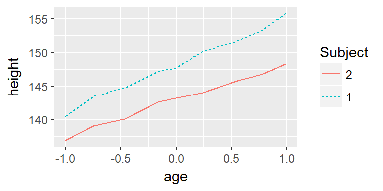

```r
(g = ggplot(data=Oxboys[1:18,], aes(age, height, col=Subject, linetype=Subject)) + geom_line())
```

```r
VI(g)
```

```
This is an untitled chart with no subtitle or caption.
It has x-axis 'age' with labels -1.0, -0.5, 0.0, 0.5 and 1.0.
It has y-axis 'height' with labels 140, 145, 150 and 155.
There is a legend indicating that colour is used to represent Subject, with 2 levels:
2 represented by colour #F8766D and
1 represented by colour #00BFC4.
There is a legend indicating that linetype is used to represent Subject, with 2 levels:
2 represented by linetype solid and
1 represented by linetype 22.
The chart is a set of 2 lines.
Line 1 connects 9 points, at (-1, 136.9), (-0.75, 139.1), (-0.46, 140.1), (-0.16, 142.6), (0, 143.2), (0.25, 144), (0.56, 145.8), (0.78, 146.8) and (0.99, 148.3).
This line has colour #F8766D which maps to Subject = 2.
This line has line type solid which maps to Subject = 2.
Line 2 connects 9 points, at (-1, 140.5), (-0.75, 143.4), (-0.46, 144.8), (-0.16, 147.1), (0, 147.7), (0.25, 150.2), (0.56, 151.7), (0.78, 153.3) and (0.99, 155.8).
This line has colour #00BFC4 which maps to Subject = 1.
This line has line type 22 which maps to Subject = 1.
```

This issue could potentially be addressed by examining the object produced by ggplot_gtable, which creates the lower-level grid representation of the graphic. Examination of that object would show that there is in fact only one guide being displayed, rather than two. However, in cases with multiple guides, only some of which were merged, care would be needed to identify the correct ones. Alternatives would be to replicate the merge logic within VI.ggplot, or to call the internal ggplot2 merge function.

## 5.2 MakeAccessibleSVG method limitations

Due to time constraints the developed implementation of MakeAccessibleSVG.ggplot is quite limited. It correctly displays, highlights and allows navigation for simple (non-faceted, single-layer, non-stacked) histograms with a continuous x-axis. With ggplot2 it is of course possible to create a much wider variety of histograms, as well as the many other geoms available.

Issues can arise even for the simple histograms currently supported when x or y limits are set on the plot, meaning that bars are calculated but not visible because they fall outside the plot limits. In these cases the MakeAccessibleSVG.ggplot implementation may provide misleading descriptions, or may highlight the incorrect bar in its display. It should be noted that the existing MakeAccessibleSVG method for base R histograms suffers from similar issues when plot limits are specified.

These issues arise because the mapping between graphical objects and the corresponding items in the SVG representation is done positionally (i.e. the first data row is assumed to correspond to the first visible bar, and so on). This assumption is fragile and may not be correct when reporting on objects that are hidden from display because they have missing values or are outside the plot boundaries. It would be preferable if a more robust method of identifying the corresponding items could be found. Failing that, the various special cases will need to be carefully catered for when further developing or extending MakeAccessibleSVG.ggplot.

MakeAccessibleSVG.ggplot currently constructs its text descriptions within the programming logic that builds the XML. It would likely be preferable, and relatively straightforward, to use the templating system instead for this purpose, as it is used for VI.ggplot. The templating function has been designed to be able to translate a collection of objects at once, returning a text string for each, should that functionality be required by MakeAccessibleSVG.

The author experimented briefly with extending MakeAccessibleSVG.ggplot to process the “line” geom as well. It was found that visually highlighting the individual segments of a line was complicated by the fact that the entire line is one object within the SVG. This should be possible to overcome with an additional step post-processing the SVG to replace the composite line with individual segments which could then be individually highlighted by the JavaScript; and in fact similar functionality already exists within the MakeAccessibleSVG method for base R time series plots, which could be leveraged.

# 6 Discussion

## 6.1 Future directions

Further development of the MakeAccessibleSVG functionality for ggplot objects is an obvious target for future research. If the issue of component mapping as described above can be successfully resolved, it should be possible to extend its functionality, not only to additional basic geoms, but to more complex plots containing multiple layers or facets. For the more complex plots especially, the ability to hierarchically explore their contents would likely be very helpful in supporting the blind user’s understanding.

There is significant scope to explore alternative presentations of the same extracted data. As an example, consider a scatter plot created by ggplot, with colour used to represent a third variable, and shape a fourth. In the current VI method, the output would (if the number of points is below the specified threshold) simply list all the points one by one, with their coordinates, colours and shapes, mapping back to the original values where possible. But depending on the user’s information needs, they might or might not wish:

- to hear the exact colours and shapes used in the graphic
- to hear all the points for colour 1, followed by colour 2, and so on, irrespective of shape
- to hear all the points for shape 1, followed by shape 2, and so on, irrespective of colour
- to hear summaries of the points rather than the details (e.g. how many points are in each quadrant of the graph). They could want these grouped by the aesthetics or not.
- to hear about the positioning and formatting of the axes, legend, and annotations

Now that a framework has been put in place, these varying needs could be met in a number of ways:

- Interactive exploration using MakeAccessibleSVG
- Filtering functions. The concept of filtering was demonstrated via two very simple functions. Additional, more substantial filters could be developed to allow flexible querying of the VIstruct object. These could enable the user to examine the graph in their own preferred sequence and to whatever depth they need, rather than being presented with a large block of text presented in a pre-defined order.
- Additional tools that could be developed to explore the created object in as-yet unforeseen ways

At a more basic level, adding support for additional geoms in VI.ggplot should be fairly straightforward. Unlike when working with base R graphics, the overarching ggplot2 framework is consistent across the geoms, so only a few aspects of the processing vary by geom:

- Different values need to be captured and reported for each geom: points have an x and y value plus the aesthetics, while box plots for example have more values of interest. This affects the extraction logic as well as the mustache template.
- Some processing differs based on whether the geom is a collective or individual one. For a point geom, each row of stored data corresponds to an individual item to be reported. Lines on the other hand have one data row per point, but it is desirable to report about the line as a whole as well as listing the points within it.

Undoubtedly there are ways in which the language of the VI.ggplot text descriptions could be improved. The current descriptions for stacked bar graphs, as an example, are rather wordy and not likely to be the ideal textual representation (some recent feedback from Dr Godfrey has suggested improvements in this area).

The developers of the iGraph-Lite system say that it “was developed after several studies involving professional statisticians and statistical communication officers interacting about graphs with blind and vision-impaired individuals, decanting the vocabulary most likely to help graph accessibility”. A more detailed review of their work could inform the system’s language usage. The templating system makes such changes generally straightforward to implement.

Investigations, using eye trackers, into how sighted users consume graphics (the sequence in which components are explored, which items are returned to multiple times, etc.) might provide ideas about how best to support similar exploration for blind users. Of course validation would be needed with blind users as to the utility of any such approach.

## 6.2 Conclusion

It may be appropriate at this point to compare the developed system to others from the literature. Many of the reviewed systems, especially the sonification and haptic ones, are aimed primarily at giving the user a sort of gestalt appreciation of what might be called the shape of the data – concepts such as “how does the y value rise and fall as we move along the x-axis”. Those systems are typically aimed at quite simple graphics, often of a single type (e.g. line graphs), and focused on the “content” portion of the graphic.

The work described in this dissertation occupies a somewhat different niche. The focus is on useful description of the numerous different and potentially complex graphs supported by ggplot. The *framework* of the graph is a particular focus - its layout, annotation, layer structure, aesthetics, and the like. In addition to the framework, the data detail is also extracted and is straightforwardly listed, including any aesthetics used to convey information.

The problem of making potentially large volumes of data accessible is undoubtedly a difficult one. Any of the methods described in the literature (sonification, haptic, etc.), or ones not yet developed, could potentially be combined with the system described herein to support a further understanding of the extracted data detail. Simpler text based methods of summarisation could also be applied, and some relevant functionality in that direction already exists within BrailleR. In this way, the work of this dissertation can be seen as complementary to other research in data exploration for blind users. It may also be expected that users of BrailleR, having access to the data within the R statistical environment, are able to explore the detail in more statistical ways, giving them yet another vector for understanding.

Revisiting the goals expressed by the participants in Ferres et al’s study(Ferres et al. 2006), they identified the following requests:

- to hear the purpose, type and title (main and axes) of the graph first
- to describe the graph point-by-point (while acknowledging that this might only be useful for simple graphs)
- to describe the general trend and then the details

The system described herein provides a structure for satisfying the first two of these goal (and providing much additional framework description where relevant), while other research may contribute more toward making the general trends in the data accessible.

The original motivations behind exploring the possibility of expanding VI to report on ggplot2 graphics included:

- ggplot2 is a popular graphics system likely to be encountered in classrooms and elsewhere
- ggplot2 can produce additional types of graphs and more complex graphics compared to the base R graphics functions that were then supported by VI
- once a method for ggplot2 was created, extending it to report for additional plot types would be relatively easy
- because it returns an object structure and is built atop grid graphics, ggplot2 would be amenable to examination of the structure of the graphics it produces

Exploration has borne out the validity of this thinking for the most part. It has been possible to extract the needed information to produce meaningful descriptions of a wide variety of ggplot2 graphics. Access to the underlying grid object and use of the gridSVG function makes it possible to support interactive exploration as well. The potential for further extension and improvement seems substantial.

The developed methods have been incorporated into the BrailleR package source code for inclusion in an upcoming release. The author hopes that this new functionality will be of benefit to blind users of R, and that they will provide feedback to enable continued future improvement.

# Appendix 1 - Example output

This appendix contains full output from VI for some additional ggplot2 graphics, beyond those shown in the main text. These examples are chosen to illustrate some additional features of the output which haven’t yet been demonstrated. In some cases the data sets have been subsetted to keep the output size reasonable.

The example below shows a faceted graph with a “points” geom. It can be seen that the title and overridden axis labels are reported. The plot has a log-scale y axis (so the y positions stored within the ggplot_build object are transformed). Nonetheless the original non-transformed values are correctly reported. The “margins=TRUE” command has used to create an “ALL” panel, which is also reported.

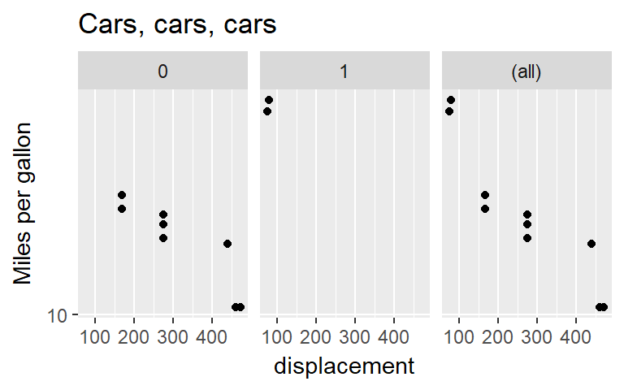

```r
m= within(mtcars,{am = as.factor(am); cyl = as.factor(cyl)})

(x = qplot(data=m[10:19,], disp, mpg, facets=.~am, margins=TRUE,
    geom="point", main="Cars, cars, cars", xlab="displacement",
    ylab="Miles per gallon", log="y"))
```

```r
VI(x)
```

```
This chart has title 'Cars, cars, cars'.
The chart is comprised of 3 panels containing sub-charts, arranged horizontally.
The panels represent different values of am.
Each sub-chart has x-axis 'displacement' with labels 100, 200, 300 and 400.
Each sub-chart has y-axis 'Miles per gallon' with labels 10.
Panel 1 represents data for am = 0.
Panel 1 is a set of 8 points.
The points are at:
(167.6, 19.2),
(167.6, 17.8),
(275.8, 16.4),
(275.8, 17.3),
(275.8, 15.2),
(472, 10.4),
(460, 10.4) and
(440, 14.7)
Panel 2 represents data for am = 1.
Panel 2 is a set of 2 points.
The points are at:
(78.7, 32.4) and
(75.7, 30.4)
Panel 3 represents data for am = (all).
Panel 3 is a set of 10 points.
The points are at:
(167.6, 19.2),
(167.6, 17.8),
(275.8, 16.4),
(275.8, 17.3),
(275.8, 15.2),
(472, 10.4),
(460, 10.4),
(440, 14.7),
(78.7, 32.4) and
(75.7, 30.4)
```

The chart below is a stacked histogram with the bar detail reported. It can be seen that each sub-bar is currently reported individually, including those with zero height. The author hopes to make future improvements so that the stacked bars are grouped more logically. The color aesthetic is reported (as hex RGB values) and mapped back to the values for the variable “cyl”.

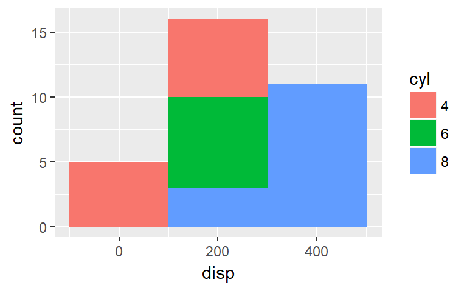

```r
(x = qplot(data=m, mapping=aes(fill=cyl), x=disp, bins=3, geom="histogram"))
```

```r
VI(x, threshold=20)
```

```
This is an untitled chart with no subtitle or caption.
It has x-axis 'disp' with labels 0, 200 and 400.
It has y-axis 'count' with labels 0, 5, 10 and 15.
There is a legend indicating that fill is used to represent cyl, with 3 levels:
4 represented by fill #F8766D,
6 represented by fill #00BA38 and
8 represented by fill #619CFF.
The chart is a bar chart containing 9 vertical bars.
Bar 1 is centered horizontally at 0, and spans vertically from 0 to 0 with fill colour #619CFF which maps to cyl = 8.
Bar 2 is centered horizontally at 0, and spans vertically from 0 to 0 with fill colour #00BA38 which maps to cyl = 6.
Bar 3 is centered horizontally at 0, and spans vertically from 0 to 5 with fill colour #F8766D which maps to cyl = 4.
Bar 4 is centered horizontally at 200.45, and spans vertically from 0 to 3 with fill colour #619CFF which maps to cyl = 8.
Bar 5 is centered horizontally at 200.45, and spans vertically from 3 to 10 with fill colour #00BA38 which maps to cyl = 6.
Bar 6 is centered horizontally at 200.45, and spans vertically from 10 to 16 with fill colour #F8766D which maps to cyl = 4.
Bar 7 is centered horizontally at 400.9, and spans vertically from 0 to 11 with fill colour #619CFF which maps to cyl = 8.
Bar 8 is centered horizontally at 400.9, and spans vertically from 11 to 11 with fill colour #00BA38 which maps to cyl = 6.
Bar 9 is centered horizontally at 400.9, and spans vertically from 11 to 11 with fill colour #F8766D which maps to cyl = 4.
```

The chart below illustrates reporting on a plot with a line geom and an x-axis variable of type date. A horizontal line overlaid as layer 2 is also reported. It can be seen that the individual points are reported with the x values as dates, and that the aesthetic (colour “blue”) set on the second layer is also reported.

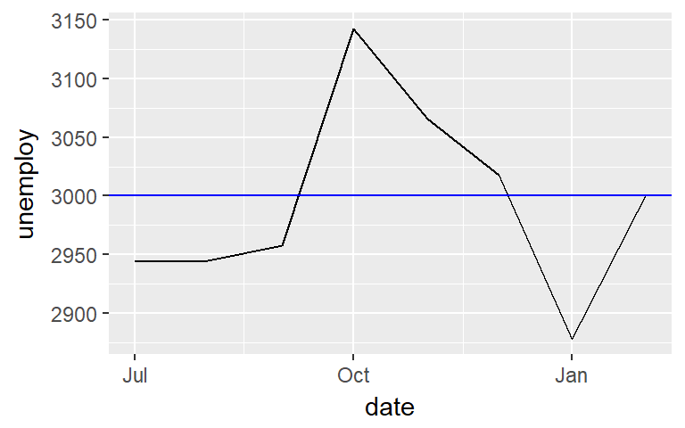

```r
(x=qplot(data=economics[1:8,], date, unemploy, geom="line") +
   geom_hline(yintercept=3000, col="blue"))
```

```r
VI(x)
```

```
This is an untitled chart with no subtitle or caption.
It has x-axis 'date' with labels Jul, Oct and Jan.
It has y-axis 'unemploy' with labels 2900, 2950, 3000, 3050, 3100 and 3150.
It has 2 layers.
Layer 1 is a set of 1 line.
Line 1 connects 8 points, at (1967-07-01, 2944), (1967-08-01, 2945), (1967-09-01, 2958), (1967-10-01, 3143), (1967-11-01, 3066), (1967-12-01, 3018), (1968-01-01, 2878) and (1968-02-01, 3001).
Layer 2 is 1 horizontal line as follows:
Line at y position 3000.
Layer 2 has colour set to blue.
```

# References

Bennett, David J. 2002. “Effects of Navigation and Position on Task When Presenting Diagrams.” In *Proceedings of the Second International Conference on Diagrammatic Representation and Inference*, 161–75. DIAGRAMS ’02. London, UK, UK: Springer-Verlag. http://dl.acm.org/citation.cfm?id=645971.675066.

Brown, Andy, Steve Pettifer, and Robert Stevens. 2003. “Evaluation of a Non-Visual Molecule Browser.” *SIGACCESS Access. Comput.*, no. 77-78 (September). New York, NY, USA: ACM: 40–47. doi:10.1145/1029014.1028639.

Calder, Matt, Robert F. Cohen, Jessica Lanzoni, and Yun Xu. 2006. “PLUMB: An Interface for Users Who Are Blind to Display, Create, and Modify Graphs.” In *Proceedings of the 8th International Acm Sigaccess Conference on Computers and Accessibility*, 263–64. Assets ’06. New York, NY, USA: ACM. doi:10.1145/1168987.1169046.

Corio, Marc, and Guy Lapalme. 1999. “Generation of Texts for Information Graphics.” In *IN Proceedings of the 7TH European Workshop on Natural Language Generation Ewnlg’99*, 49–58.

Demir, Seniz, David Oliver, Edward Scfhwartz, Stephanie Elzer, Sandra Carberry, and Kathleen F. McCoy. 2010. “Interactive Sight into Information Graphics.” In *Proceedings of the 2010 International Cross Disciplinary Conference on Web Accessibility (W4a)*, 16:1–16:10. W4A ’10. New York, NY, USA: ACM. doi:10.1145/1805986.1806009.

Elzer, Stephanie, Edward Schwartz, Sandra Carberry, Daniel Chester, Seniz Demir, and Peng Wu. 2007. “A Browser Extension for Providing Visually Impaired Users Access to the Content of Bar Charts on the Web.” In *WEBIST (2)*, 59–66.

Erhardt, Robert J., and Michael P. Shuman. 2015. “Assistive Technologies for Second-Year Statistics Students Who Are Blind.” *Journal of Statistics Education* 23 (2). https://ww2.amstat.org/publications/jse/v23n2/erhardt.pdf.

Fartaria, Rui P. S., Florbela Pereira, Vasco D. B. Bonifácio, Paulina Mata, João Aires-de-Sousa, and Ana M. Lobo. 2013. “NavMol 2.0 – a Molecular Structure Navigator/Editor for Blind and Visually Impaired Users.” *European Journal of Organic Chemistry* 2013 (8). WILEY-VCH Verlag: 1415–9. doi:10.1002/ejoc.201201458.

Fasciano, Massimo, and Guy Lapalme. 1996. “PostGraphe: A System for the Generation of Statistical Graphics and Text.” In *IN Proceedings of the 8TH International Natural Language Generation Workshop*, 51–60.

Ferres, Leo, Avi Parush, Shelley Roberts, and Gitte Lindgaard. 2006. “Helping People with Visual Impairments Gain Access to Graphical Information Through Natural Language: The Igraph System.” In *ICCHP*, 1122–30. Springer.

Ferres, Leo, Petro Verkhogliad, Gitte Lindgaard, Louis Boucher, Antoine Chretien, and Martin Lachance. 2007. “Improving Accessibility to Statistical Graphs: The IGraph-Lite System.” In *Proceedings of the 9th International Acm Sigaccess Conference on Computers and Accessibility*, 67–74. Assets ’07. New York, NY, USA: ACM. doi:10.1145/1296843.1296857.

Fitzpatrick, Donal, A. Jonathan R. Godfrey, and Volker Sorge. 2017. “Producing Accessible Statistics Diagrams in R.” In *Proceedings of the 14th Web for All Conference on the Future of Accessible Work*, 22:1–22:4. W4A ’17. New York, NY, USA: ACM. doi:10.1145/3058555.3058564.

Godfrey, A. Jonathan R. 2013. “Statistical Software from a Blind Person’s Perspective.” *The R Journal* 5 (1): 73–79. https://journal.r-project.org/archive/2013/RJ-2013-007/index.html.

Godfrey, A. Jonathan R., and M. Theodor Loots. 2014. “Statistical Software (R, Sas, Spss, and Minitab) for Blind Students and Practitioners.” *Journal of Statistical Software, Software Reviews* 58 (1): 1–25. doi:10.18637/jss.v058.s01.

———. 2015. “Advice from Blind Teachers on How to Teach Statistics to Blind Students.” *Journal of Statistics Education* 23 (3). https://ww2.amstat.org/publications/jse/v23n3/godfrey.pdf.

Godfrey, A. Jonathan R., Paul Murrell, and Volker Sorge. 2017. “Interactive Graphs for Blind and Print Disabled People.” In *useR!2017*. Brussels. https://user2017.sched.com/event/AxqW/interactive-graphs-for-blind-and-print-disabled-people.

Godfrey, A. Jonathan R., fVolker Sorge, and Timothy P. Bilton. 2017. *BrailleR: Improved Access for Blind Users*. Massey University. https://cran.r-project.org/package=BrailleR.

Kukich, Karen. 1983. “Design of a Knowledge-Based Report Generator.” In *Proceedings of the 21st Annual Meeting on Association for Computational Linguistics*, 145–50. ACL ’83. Stroudsburg, PA, USA: Association for Computational Linguistics. doi:10.3115/981311.981340.

McGookin, David K., and Stephen A. Brewster. 2006. “MultiVis: Improving Access to Visualisations for Visually Impaired People.” In *CHI ’06 Extended Abstracts on Human Factors in Computing Systems*, 267–70. CHI Ea ’06. New York, NY, USA: ACM. doi:10.1145/1125451.1125509.

Mittal, Vibhu O., Giuseppe Carenini, Johanna D. Moore, and Steven Roth. 1998. “Describing Complex Charts in Natural Language: A Caption Generation System.” *Computational Linguistics* 24 (3). Cambridge, MA, USA: MIT Press: 431–67. http://www.aclweb.org/anthology/J98-3004?CFID=819445614&CFTOKEN=95255647.

Murrell, Paul. 2017. *GridGraphics: Redraw Base Graphics Using ’Grid’ Graphics*. https://CRAN.R-project.org/package=gridGraphics.

Murrell, Paul, and Simon Potter. 2017. *GridSVG: Export ’Grid’ Graphics as Svg*. https://CRAN.R-project.org/package=gridSVG.

R Core Team. 2017. *R: A Language and Environment for Statistical Computing*. Vienna, Austria: R Foundation for Statistical Computing. https://www.R-project.org/.

Ramloll, Rameshsharma, Wai Yu, Stephen Brewster, Beate Riedel, Mike Burton, and Gisela Dimigen. 2000. “Constructing Sonified Haptic Line Graphs for the Blind Student: First Steps.” In *Proceedings of the Fourth International Acm Conference on Assistive Technologies*, 17–25. Assets ’00. New York, NY, USA: ACM. doi:10.1145/354324.354330.

SAS Institute Inc. 2017. “SAS® Graphics Accelerator.” Accessed September 18. http://support.sas.com/software/products/graphics-accelerator.

Siegert, Stefan, and Robin Williams. 2017. *Sonify: Data Sonification - Turning Data into Sound*. https://CRAN.R-project.org/package=sonify.

Sorge, Volker, Mark Lee, and Sandy Wilkinson. 2015. “End-to-End Solution for Accessible Chemical Diagrams.” In *Proceedings of the 12th Web for All Conference*, 6:1–6:10. W4A ’15. New York, NY, USA: ACM. doi:10.1145/2745555.2746667.

Stevens, Robert, and Alistair Edwards. 1994. “Mathtalk: The Design of an Interface for Reading Algebra Using Speech.” In *Computers for Handicapped Persons: 4th International Conference, Icchp ’94 Vienna, Austria, September 14–16, 1994 Proceedings*, edited by Wolfgang L. Zagler, Geoffrey Busby, and Roland R. Wagner, 313–20. Berlin, Heidelberg: Springer Berlin Heidelberg. doi:10.1007/3-540-58476-5_146.

Travis CI, GmbH. 2017. “Travis CI.” Accessed October 8. https://travis-ci.org.

UK Association for Accessible Formats. 2017. “Accessible Images.” Accessed September 28. https://www.ukaaf.org/accessible-images/.

Wickham, Hadley. 2016. *Ggplot2: Elegant Graphics for Data Analysis*. Springer.

Yu, Wai, K. Kangas, and S. Brewster. 2003. “Web-Based Haptic Applications for Blind People to Create Virtual Graphs.” In *11th Symposium on Haptic Interfaces for Virtual Environment and Teleoperator Systems, 2003. Haptics 2003. Proceedings.*, 318–25. doi:10.1109/HAPTIC.2003.1191301.